# Linear model selection and regularization

### K-fold cross validation

Randomly divide the data set into \( K \) nonoverlapping groups, or *folds*, of roughly equal size.

For fold k = 1 to K:

- Fit the model using all data points not in fold \( i \).
- For all points \( (y_i, x_i) \) in fold \( k \), predict \( \hat{y_i} \) using the fitted model.
- Calculate \( \mathrm{Err}_k \), the average error on fold \( k \).

Estimate the error rate as: \[ \mathrm{CV}_{(K)} = \frac{1}{K} \sum_{k=1}^K \mathrm{Err}_k \]

### 10-fold CV: quick example

Back to the ethanol data:

```r
N = nrow(ethanol)

# Create a vector of fold indicators
K = 10
fold_id = rep_len(1:K, N)  # repeats 1:K over and over again
fold_id = sample(fold_id, replace=FALSE) # permute the order randomly

err_save = rep(0, K)
for(i in 1:K) {
  train_set = which(fold_id != i)
  y_test = ethanol$NOx[-train_set]
  poly5 = lm(NOx ~ poly(E, 5), data=ethanol[train_set,])
  yhat_test = predict(poly5, newdata=ethanol[-train_set,])
  err_save[i] = mean((y_test - yhat_test)^2)
}
# RMSE
sqrt(mean(err_save))
```

```
[1] 0.3653257
```

### K-fold cross validation

- Generally requires less computation than LOOCV (K refits, versus N). If N is extremely large, LOOCV is almost certainly infeasible.
- More stable (lower variance) than running \( K \) random train/test splits.
- LOOCV is a special-case of K-fold CV (with K = N).

### K-fold CV: bias-variance tradeoff

Key insight: there is a bias-variance tradeoff in estimating test error.

Bias comes from estimating out-of-sample error using a smaller training set than the full data set.

- LOOCV: minimal bias, since using \( N-1 \) points to fit.
- K-fold: some bias, e.g. using 80% of N to fit when \( K=5 \).

### K-fold CV: bias-variance tradeoff

Key insight: there is a bias-variance tradeoff in estimating test error.

Variance comes from *overlap* in the training sets:

- In LOOCV, we average the outputs of N fitted models, each trained on *nearly identical* observations.
- In K-fold, we average the outputs of \( K \) fitted models that are less correlated, since they have less overlap in the training data. Generally *less variance* than LOOCV.

Typical values: K = 5 to K = 10 (no theory; a purely empirical observation).

### Back to regularization: software

There are many, many packages for fitting lasso regressions in R.

- `glmnet` is most common, and `gamlr` is my favorite. These two are very similar, and they share syntax.
- Side note: big difference is what they do beyond a simple lasso:. glmnet does an “elastic net” penalty, while `gamlr` does a “gamma lasso” penalty. A little beyond the scope of the course, but cool stuff.
- Since we stick mostly to lasso, they’re nearly equivalent for us. `gamlr` just makes it easier to apply some model selection rules.

Both use the Matrix library representation for sparse matrices.

### Sparse matrices

Often, your feature matrix will be very sparse (i.e, mostly zeros).

- This is especially true when you have lots of factors (categorical variables) as features.
- It is then efficient to ignore zero elements in actually storing \( X \).

A simple triplet matrix is a very common storage format:

- It only stores the nonzero elements
- The row ‘i’, column ‘j’, and entry value ‘v’.

### Sparse matrices

For example:

\[ X = \left[ \begin{array}{r r r} 0 & 0 & 3.1 \\ 1.7 & 0 & 0 \\ 0 & 0 & 0 \end{array} \right] \]

### Sparse matrices

For gamlr/glmnet you need to build your own design matrix i.e., what the \( y ∼ x1 + x2 \) formula does for you inside glm.

We've seen how to do this with `model.matrix` for dense matrices. The sparse version `sparse.model.matrix` works the same way.

We'll walk through the example in `semiconductor.R`, which shows all these ideas:

- sparse model matrices
- regularization paths
- AIC vs. cross-validation

### Dimensionality reduction

Basic idea:

- Summarize the information in the \( p \) original features into a smaller set of \( k \) *summary features* (\( k < p \)).
- Then try to predict \( y \) using the derived features.
- Summaries are often linear combinations of the original variables.

This is useful when:

- there are still too many variables (the haystack is too big).
- and/or the features are highly correlated and it doesn't make sense to just select a handful of them.

### Dimensionality reduction: example

- only 12 months per year, and perhaps 40 years of data.
- Yet *thousands* of other stocks in the market.

Could do variable selection from among these thousands of variables, but remember: each extra bit of hay we throw onto the haystack makes it harder to find the needles!

### Dimensionality reduction: example

Suppose we want to build a model for how the returns on Apple's stock depend on all other stocks in the market. So let

- \( y_t \) = return on Apple stock in month \( t \).
- \( x_{jt} \) = return on other stock \( j \) in month \( t \).

A linear model would say \[ E(y_t) = \alpha + \sum_{j=1}^p \beta_j x_{jt} + e_t \]

### Dimensionality reduction: example

So we try dimensionality reduction:  
\[ E(y_t) = \alpha + \beta m_t + e_t \] where

- \( y_t \) is the return on a stock of interest (e.g. Apple) in period \( t \)
- \( m_t \) is the “market return”, i.e. the weighted-average return on all other stocks:  
  \[ m_t = \sum_{j=1}^p w_j x_{jt} \, . \] (The weight \( w_j \) is proportional to the size of the company.)

### Dimensionality reduction: example

In finance this is called the “single index” model, a variant of the “capital asset pricing model”.

See, e.g., https://finance.yahoo.com/quote/AAPL

Look for their estimate of \( \beta \)!

### Dimensionality reduction

The single-index model filter \( p \) variables into 1 variable, via a single linear combination: \[ m = \sum_{j=1}^p w_j x_{j} \, . \]

In the case of a single-index model for stocks, it is natural to take a market-weighted linear combination of all stocks. The weights come from economics, not statistics.

But what if we don't have a natural or “obvious” set of weights?

### Dimensionality reduction: PCA

A very popular way to proceed here is Principal Components Analysis

- PCA is a dimensionality reduction technique that tries to represent \( p \) variables with a \( k < p \) new variables.
- Like in the single-index model, these “new” variables are linear combinations of the original variables.
- The hope is that a small number of them are able to effectively represent what is going on in the original data.
- We'll study PCA in detail later. For now, we'll use it as a black box “machine” for generating summary features.

### PCA: some intuition

In PCA, we extract \( K \) summary variables from each feature vector \( x_i \). Each summary \( k=1, \ldots, K \) is of the form: \[ s_{ik} = \sum_{j=1}^p v_{jk} x_{ij} \] where \( x_{ij} \) is original feature \( j \), and \( s_{ik} \) is summary feature \( k \), for observation \( i \).

The coefficients \( v_{jk} \) are the “loadings” or “weights” on the original variables. The goal of PCA is to choose an “optimal” set of weights.

### PCA: some intuition

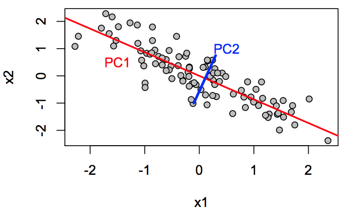

- The two variables x1 and x2 are very correlated. PC1 tells you almost everything that is going on in this dataset: \[ s_{1} = 0.781 x_1 - 0.625 x_2 \]
- PCA will look for linear combinations of the original variables that account for most of their variability.

### PCA: a simple example

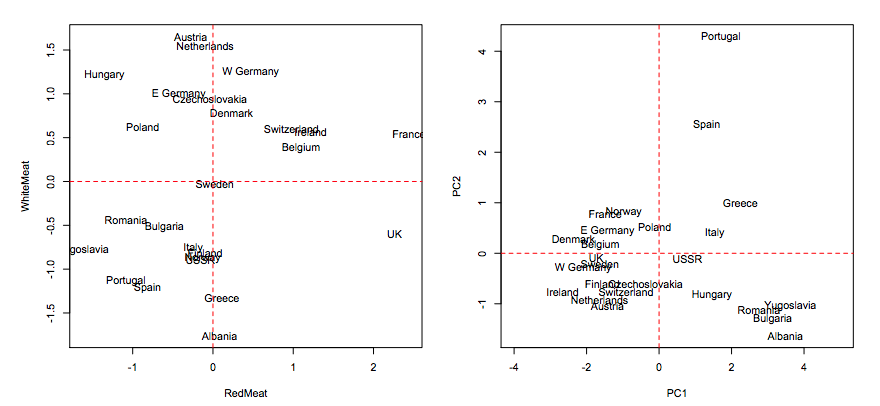

Can you interpret the summaries?

### PCA: quick summary

- PCA is a great way to “collapse” many features into few.
- The choice of K (how many summaries) can be evaluated via the out-of-sample fit.
- The units of each summary variable are not interpretable in an absolute sense—only relative to each other.
- It's always a good idea to center the data before running PCA.
- Much more on PCA later!

Let's see an example in `gasoline.R`.